# Project Report

# Data Analysis on London Bus Safety Performance

#### Data source: https://data.world/makeovermonday/2018w51

## Team:

### Kevinprakash V 20BCE1940

### Jagadish R 20BRS1229

## Problem Statement

#### There were many Bus operators operating in the City of London between the year 2015 to 2018. Many operators were involved in unfortunate incidents, which makes the performance of these operators questionable among the commuters.

## Objective

#### The objective of this project is to find out which operator performed well (i.e) which involved in least number of incidents.

## 1. Reading the data

```r
setwd("C:/Users/kevinprakash/Documents/20BCE1940/")
bus <- read.csv("bus.csv", header = TRUE, sep =",")
```

## 2. Loading the packages

```r
library("dplyr")
```

```r
library(ggplot2)
```

## 3. Summary of the dataset

```r
summary(bus)
```

```
##       Year      Date.Of.Incident      Route             Operator
##  Min.   :2015   Length:23158       Length:23158       Length:23158
##  1st Qu.:2016   Class :character   Class :character   Class :character
##  Median :2016   Mode  :character   Mode  :character   Mode  :character
##  Mean   :2016
##  3rd Qu.:2017
##  Max.   :2018
##   Group.Name         Bus.Garage          Borough
##  Length:23158       Length:23158       Length:23158
##  Class :character   Class :character   Class :character
##  Mode  :character   Mode  :character   Mode  :character
##
##
##
##  Injury.Result.Description Incident.Event.Type Victim.Category
##  Length:23158              Length:23158        Length:23158
##  Class :character          Class :character    Class :character
##  Mode  :character          Mode  :character    Mode  :character
##
##
##
##  Victims.Sex        Victims.Age
##  Length:23158       Length:23158
##  Class :character   Class :character
##  Mode  :character   Mode  :character
##
##
##
```

## 4. Data Cleaning

```r
glimpse(bus)
```

```
## Rows: 23,158
## Columns: 12
## $ Year                      <int> 2015, 2015, 2015, 2015, 2015, 2015, 2015, 20~
## $ Date.Of.Incident          <chr> "01-01-2015", "01-01-2015", "01-01-2015", "0~
## $ Route                     <chr> "1", "4", "5", "5", "6", "6", "8", "9", "10"~
## $ Operator                  <chr> "London General", "Metroline", "East London"~
## $ Group.Name                <chr> "Go-Ahead", "Metroline", "Stagecoach", "Stag~
## $ Bus.Garage                <chr> "Garage Not Available", "Garage Not Availabl~
## $ Borough                   <chr> "Southwark", "Islington", "Havering", "None ~
## $ Injury.Result.Description <chr> "Injuries treated on scene", "Injuries treat~
## $ Incident.Event.Type       <chr> "Onboard Injuries", "Onboard Injuries", "Onb~
## $ Victim.Category           <chr> "Passenger", "Passenger", "Passenger", "Pass~
## $ Victims.Sex               <chr> "Male", "Male", "Male", "Male", "Female", "F~
## $ Victims.Age               <chr> "Child", "Unknown", "Elderly", "Elderly", "E~
```

```r
summary(bus)
```

```
##       Year      Date.Of.Incident      Route             Operator
##  Min.   :2015   Length:23158       Length:23158       Length:23158
##  1st Qu.:2016   Class :character   Class :character   Class :character
##  Median :2016   Mode  :character   Mode  :character   Mode  :character
##  Mean   :2016
##  3rd Qu.:2017
##  Max.   :2018
##   Group.Name         Bus.Garage          Borough
##  Length:23158       Length:23158       Length:23158
##  Class :character   Class :character   Class :character
##  Mode  :character   Mode  :character   Mode  :character
##
##
##
##  Injury.Result.Description Incident.Event.Type Victim.Category
##  Length:23158              Length:23158        Length:23158
##  Class :character          Class :character    Class :character
##  Mode  :character          Mode  :character    Mode  :character
##
##
##
##  Victims.Sex        Victims.Age
##  Length:23158       Length:23158
##  Class :character   Class :character
##  Mode  :character   Mode  :character
##
##
##
```

```r
class(bus$Victims.Sex)
```

```
## [1] "character"
```

```r
unique(bus$Victims.Sex)
```

```
## [1] "Male"    "Female"  "Unknown"
```

```r
bus$Victims.Sex <- as.factor(bus$Victims.Sex)
glimpse(bus)
```

```
## Rows: 23,158
## Columns: 12
## $ Year                      <int> 2015, 2015, 2015, 2015, 2015, 2015, 2015, 20~
## $ Date.Of.Incident          <chr> "01-01-2015", "01-01-2015", "01-01-2015", "0~
## $ Route                     <chr> "1", "4", "5", "5", "6", "6", "8", "9", "10"~
## $ Operator                  <chr> "London General", "Metroline", "East London"~
## $ Group.Name                <chr> "Go-Ahead", "Metroline", "Stagecoach", "Stag~
## $ Bus.Garage                <chr> "Garage Not Available", "Garage Not Availabl~
## $ Borough                   <chr> "Southwark", "Islington", "Havering", "None ~
## $ Injury.Result.Description <chr> "Injuries treated on scene", "Injuries treat~
## $ Incident.Event.Type       <chr> "Onboard Injuries", "Onboard Injuries", "Onb~
## $ Victim.Category           <chr> "Passenger", "Passenger", "Passenger", "Pass~
## $ Victims.Sex               <fct> Male, Male, Male, Male, Female, Female, Male~
## $ Victims.Age               <chr> "Child", "Unknown", "Elderly", "Elderly", "E~
```

```r
bus[ bus == "Unknown" ] <- NA
newbus <- na.omit(bus)
View(newbus)
class(newbus$Victims.Sex)
```

```
## [1] "factor"
```

```r
levels(newbus$Victims.Sex)
```

```
## [1] "Female"  "Male"    "Unknown"
```

## 5. Names of the columns

```r
names(newbus)
```

```
##  [1] "Year"                      "Date.Of.Incident"
##  [3] "Route"                     "Operator"
##  [5] "Group.Name"                "Bus.Garage"
##  [7] "Borough"                   "Injury.Result.Description"
##  [9] "Incident.Event.Type"       "Victim.Category"
## [11] "Victims.Sex"               "Victims.Age"
```

## 6. Years of incidents occured

```r
unique(newbus$Year)
```

```
## [1] 2015 2016 2017 2018
```

## 7. Number of incidents occurred between 2015 and 2018

```r
event_count <- table(newbus$Incident.Event.Type)
event_count
```

```
##
## Activity Incident Event                 Assault      Collision Incident
##                      84                     510                    2798
##                    Fire        Onboard Injuries         Personal Injury
##                       3                    3920                    2929
##                 Robbery Safety Critical Failure          Slip Trip Fall
##                       3                      48                    4962
##   Vandalism Hooliganism
##                      55
```

## 8. Gender wise victim count between 2015 and 2018

```r
victim_gender_count <- table(newbus$Victims.Sex)
victim_gender_count
```

```
##
##  Female    Male Unknown
##    9090    6222       0
```

## 9. Count of incidents happened on 2015

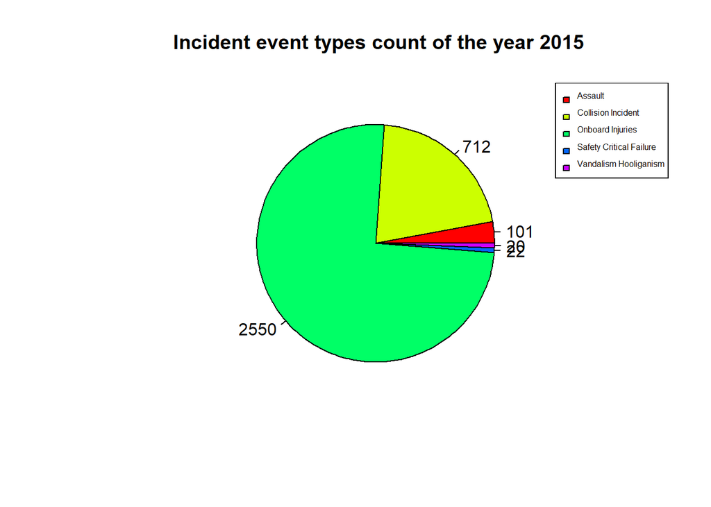

```r
bus_2015 <- filter(newbus, Year== 2015)


event_count_2015 <- table(bus_2015$Incident.Event.Type)


# count label
lbls_count_2015 <- paste( event_count_2015, sep="")


# names label
lbls_name_2015 <- paste(names(event_count_2015), "\n", sep="")



pie(event_count_2015,label= lbls_count_2015, main = " Incident event types count of the year 2015", col = rainbow(length(event_count_2015)))

legend("topright", lbls_name_2015, cex = 0.5,
       fill = rainbow(length(event_count_2015)))
```

### The count of Onboard Injuries is the highest

## 10. Count of incidents happened on 2016

```r
bus_2016 <- filter(newbus, Year== 2016)


event_count_2016 <- table(bus_2016$Incident.Event.Type)
event_count_2016
```

```
##
## Activity Incident Event                 Assault      Collision Incident
##                      23                     139                     796
##                    Fire        Onboard Injuries         Personal Injury
##                       1                    1370                     568
##                 Robbery Safety Critical Failure          Slip Trip Fall
##                       1                      15                    1136
##   Vandalism Hooliganism
##                      16
```

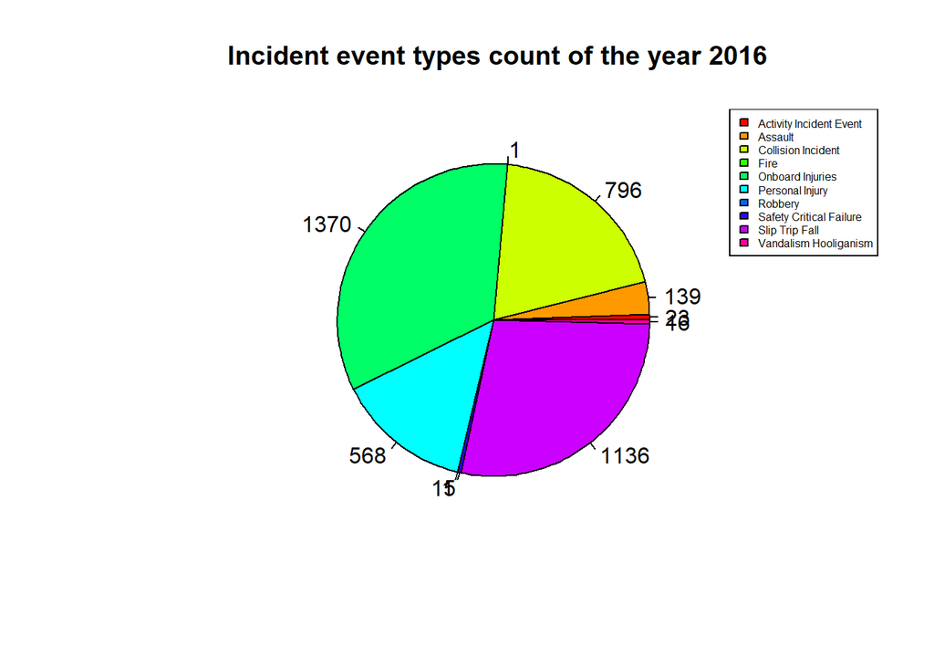

```r
# count label
lbls_count_2016 <- paste( event_count_2016, sep="")


# names label
lbls_name_2016 <- paste(names(event_count_2016), sep="")



pie(event_count_2016,label= lbls_count_2016, main = " Incident event types count of the year 2016", col = rainbow(length(event_count_2016)))

legend("topright", lbls_name_2016, cex = 0.5,
       fill = rainbow(length(event_count_2016)))
```

### The count of Onboard Injuries is the highest

## 11. Count of incidents happened on 2017

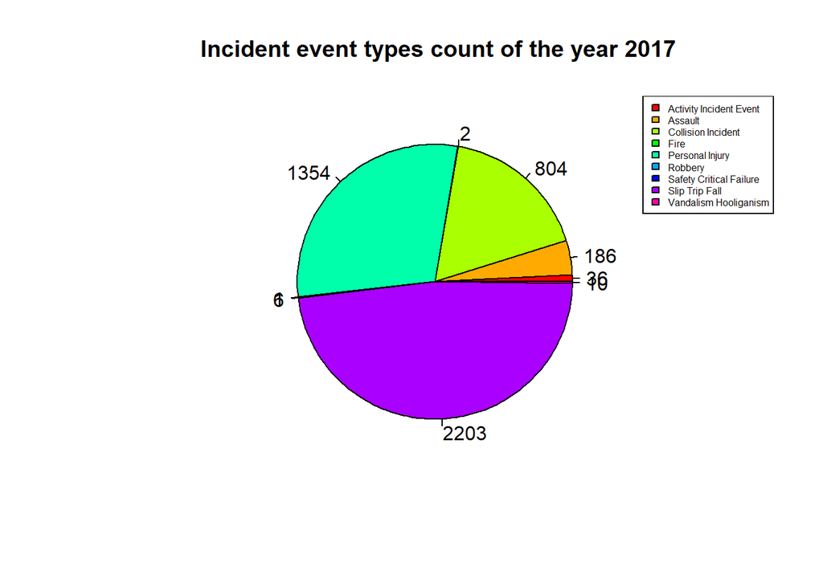

```r
bus_2017 <- filter(newbus, Year== 2017)


event_count_2017 <- table(bus_2017$Incident.Event.Type)


# count label
lbls_count_2017 <- paste( event_count_2017, sep="")


# names label
lbls_name_2017 <- paste(names(event_count_2017), sep="")



pie(event_count_2017,label= lbls_count_2017, main = " Incident event types count of the year 2017", col = rainbow(length(event_count_2017)))

legend("topright", lbls_name_2017, cex = 0.5,
       fill = rainbow(length(event_count_2017)))
```

### The count of Slip Trip Fall is the highest

## 12. Count of incidents happened on 2018

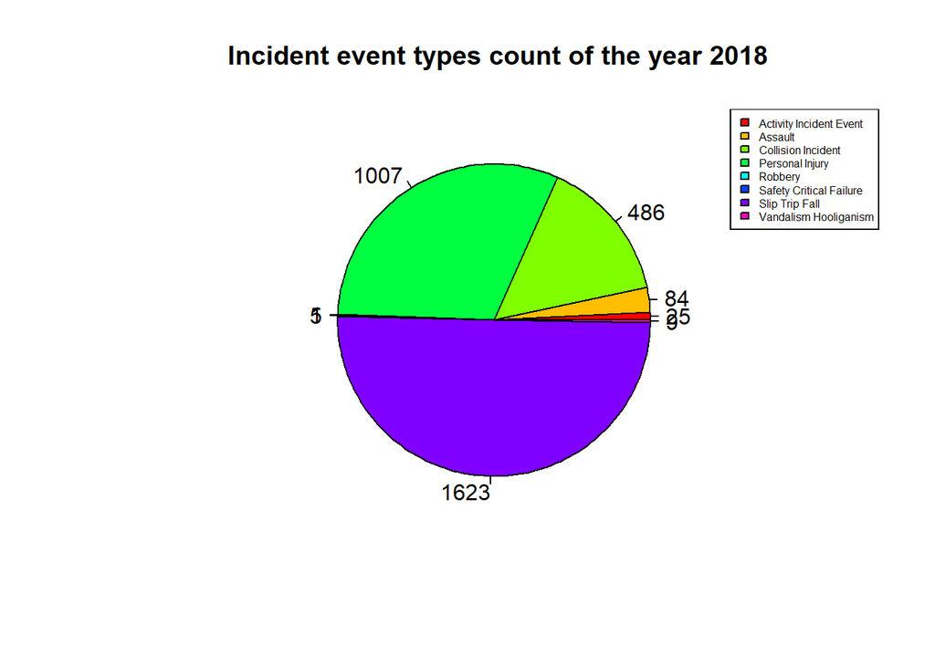

```r
bus_2018 <- filter(newbus, Year== 2018)


event_count_2018 <- table(bus_2018$Incident.Event.Type)


# count label
lbls_count_2018 <- paste( event_count_2018, sep="")


# names label
lbls_name_2018 <- paste(names(event_count_2018), sep="")



pie(event_count_2018,label= lbls_count_2018, main = " Incident event types count of the year 2018", col = rainbow(length(event_count_2018)))

legend("topright", lbls_name_2018, cex = 0.5,
       fill = rainbow(length(event_count_2018)))
```

### The count of Slip Trip Fall is the highest

## 13. Gender wise victim count of the year 2015

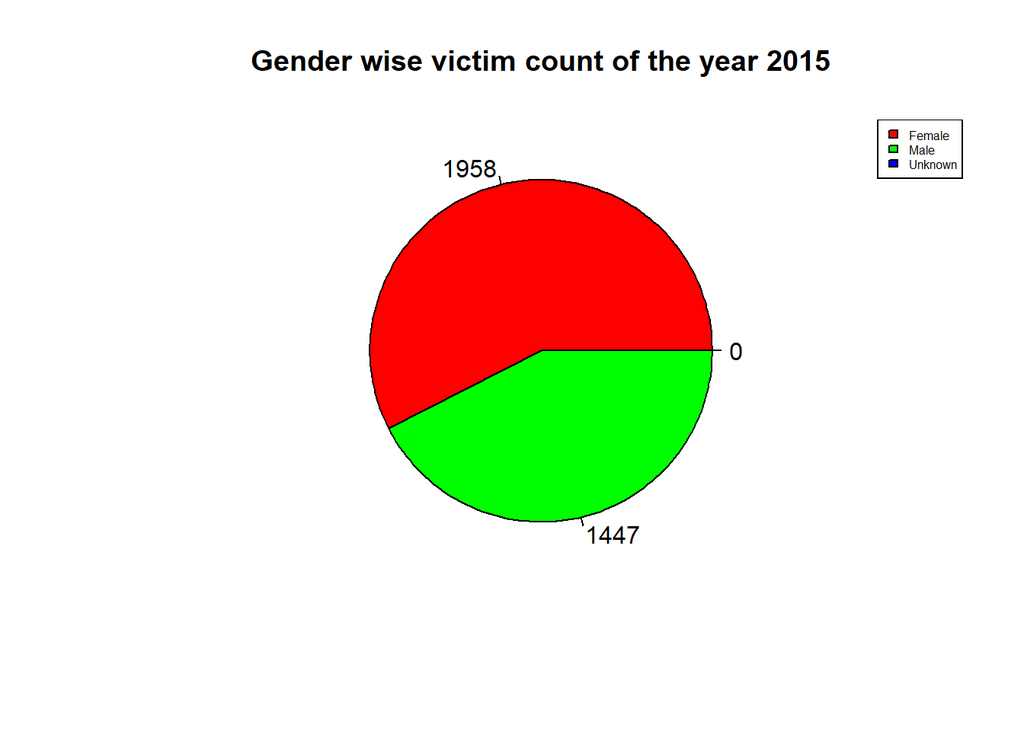

```r
sex_count_2015 <- table(bus_2015$Victims.Sex)


# count label
lbls_sex_count_2015 <- paste(sex_count_2015, sep="")


# names label
lbls_sex_name_2015 <- paste(names(sex_count_2015), sep="")



pie(sex_count_2015,label= lbls_sex_count_2015, main = "Gender wise victim count of the year 2015", col = rainbow(length(sex_count_2015)))

legend("topright", lbls_sex_name_2015, cex = 0.5,
       fill = rainbow(length(sex_count_2015)))
```

### The count of Female Victims is the highest

## 14. Gender wise victim count of the year 2016

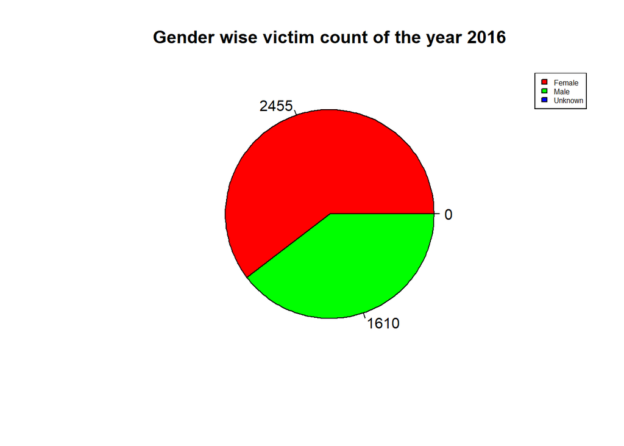

```r
sex_count_2016 <- table(bus_2016$Victims.Sex)


# count label
lbls_sex_count_2016 <- paste(sex_count_2016, sep="")


# names label
lbls_sex_name_2016 <- paste(names(sex_count_2016), sep="")



pie(sex_count_2016,label= lbls_sex_count_2016, main = "Gender wise victim count of the year 2016", col = rainbow(length(sex_count_2016)))

legend("topright", lbls_sex_name_2016, cex = 0.5,
       fill = rainbow(length(sex_count_2016)))
```

### The count of Female Victims is the highest

## 15. Gender wise victim count of the year 2017

```r
sex_count_2017 <- table(bus_2017$Victims.Sex)


# count label
lbls_sex_count_2017 <- paste(sex_count_2017, sep="")


# names label
lbls_sex_name_2017 <- paste(names(sex_count_2017), sep="")


names(sex_count_2017)
```

```
## [1] "Female"  "Male"    "Unknown"
```

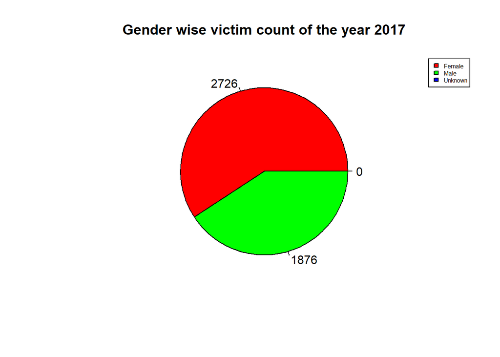

```r
pie(sex_count_2017,label= lbls_sex_count_2017, main = "Gender wise victim count of the year 2017", col = rainbow(length(sex_count_2017)))

legend("topright", lbls_sex_name_2017, cex = 0.5,
       fill = rainbow(length(sex_count_2017)))
```

### The count of Female Victims is the highest

## 15. Gender wise victim count of the year 2018

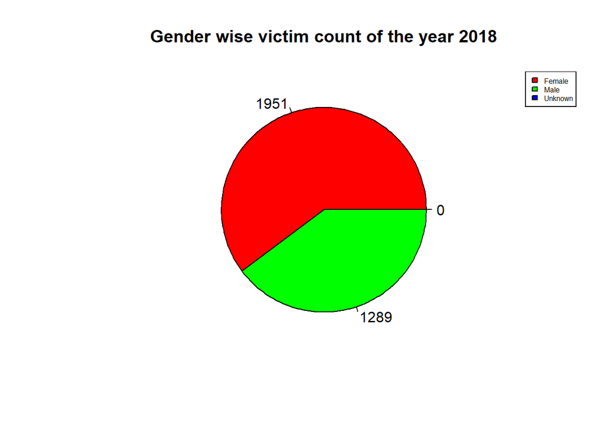

```r
sex_count_2018 <- table(bus_2018$Victims.Sex)


# count label
lbls_sex_count_2018 <- paste(sex_count_2018, sep="")


# names label
lbls_sex_name_2018 <- paste(names(sex_count_2018), sep="")



pie(sex_count_2018,label= lbls_sex_count_2018, main = "Gender wise victim count of the year 2018", col = rainbow(length(sex_count_2018)))

legend("topright", lbls_sex_name_2015, cex = 0.5,
       fill = rainbow(length(sex_count_2018)))
```

### The count of Female Victims is the highest

```r
l<-c(names(newbus))
m<-c(unique(newbus$Injury.Result.Description))
s<-l[8]
```

## 16. Safest operator

```r
safe<-newbus[which((newbus[s]==m[1])| (newbus[s]==m[3])),]
safe<-safe %>% count(safe$Operator)
head(safe)
```

```
##           safe$Operator    n
## 1        Abellio London  548
## 2          Abellio West   78
## 3 Arriva Kent Thameside   73
## 4   Arriva London North 1162
## 5   Arriva London South  619
## 6     Arriva The Shires  118
```

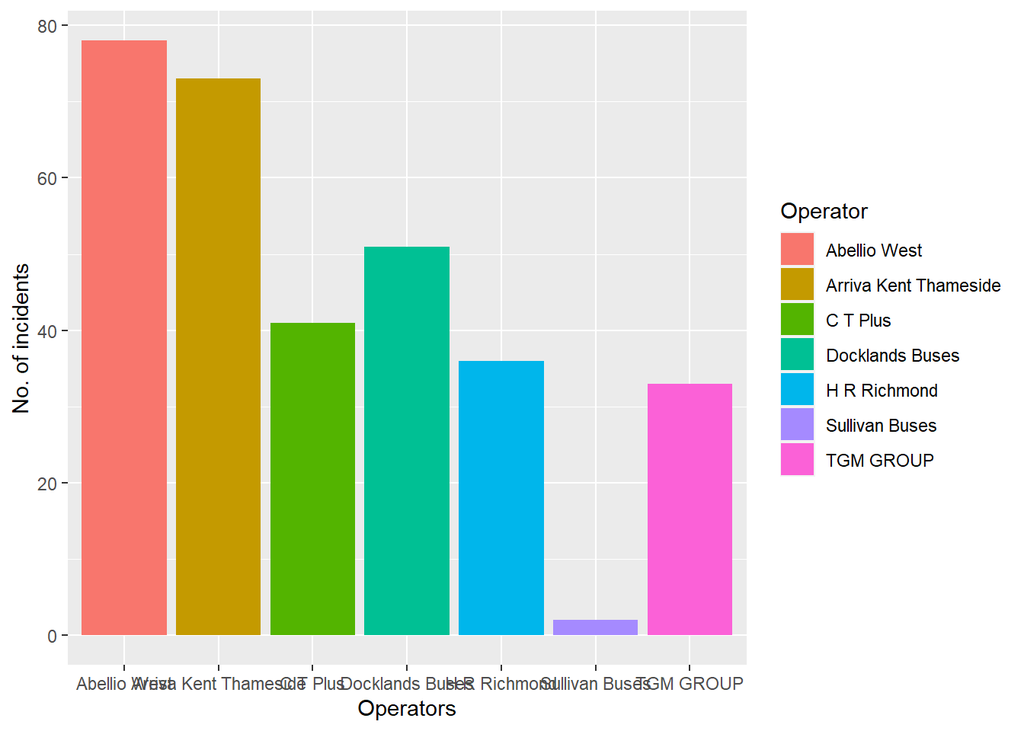

```r
names(safe)<-c("Operator","Counts")
safe_operator<-as.data.frame(safe[which(safe['Counts']<100),])
names(safe_operator)<-c("Operator","Counts")
ggplot(data=safe_operator) + geom_bar(mapping = aes(x=Operator,y=Counts,fill=Operator),stat="identity")+ xlab("Operators") + ylab("No. of incidents")
```

### The safest operator is “Sullivan Buses”

## 17. Incidents analysis of the safest operator

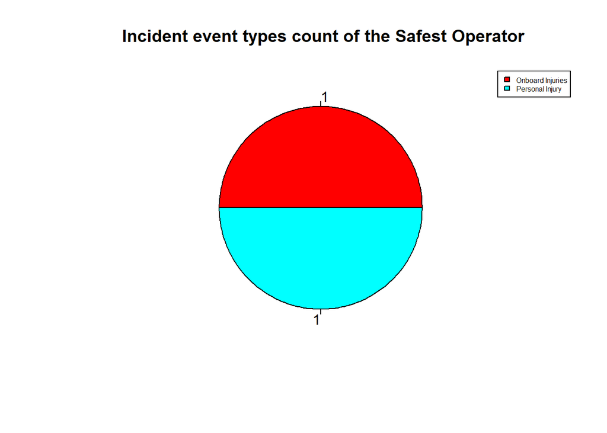

```r
safest_operator <- filter(newbus, Operator== "Sullivan Buses")


event_count_safest <- table(safest_operator$Incident.Event.Type)


# count label safest

lbls_count_safest <- paste( event_count_safest, sep="")


# names label safest
lbls_name_safest <- paste(names(event_count_safest), sep="")



pie(event_count_safest,label= lbls_count_safest, main = " Incident event types count of the Safest Operator", col = rainbow(length(event_count_safest)))

legend("topright", lbls_name_safest, cex = 0.5,
       fill = rainbow(length(event_count_safest)))
```

### Since the safest operator we obtained from the list was in the operation for just 1 year, we reject it.

## 18. Safest borough with least number of incidents involved.

```r
safe<-newbus[which((newbus[s]==m[1])| (newbus[s]==m[3])),]
safe<-safe %>% count(safe$Borough)
head(safe)
```

```
##         safe$Borough   n
## 1 Barking & Dagenham 165
## 2             Barnet 540
## 3             Bexley 244
## 4              Brent 625
## 5            Bromley 348
## 6             Camden 510
```

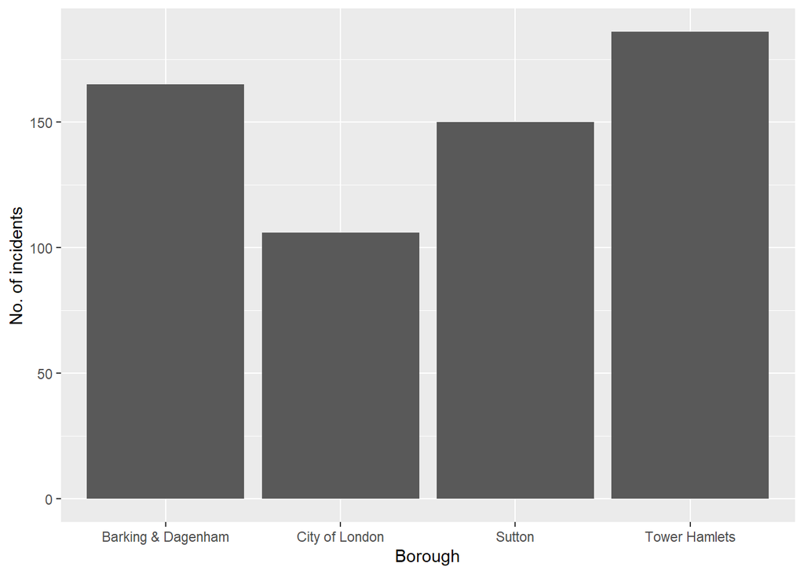

```r
names(safe)<-c("Borough","Counts")
safe_borough<-as.data.frame(safe[which(safe['Counts']<200),])
names(safe_borough)<-c("Borough","Counts")
ggplot(data=safe_borough) + geom_bar(mapping = aes(x=Borough,y=Counts),stat="identity")+ xlab("Borough") + ylab("No. of incidents")
```

### City of London is the safest borough where Operators have involved in least number of incidents.

## 19. Safest operator, which was in operation for the entire 4 years

```r
op_2015<-as.vector(newbus[which(newbus$Year==2015),c("Operator")])
op_2016<-as.vector(newbus[which(newbus$Year==2016),c("Operator")])
op_2017<-as.vector(newbus[which(newbus$Year==2017),c("Operator")])
op_2018<-as.vector(newbus[which(newbus$Year==2018),c("Operator")])
com_op<-intersect(c(op_2015,op_2016),c(op_2017,op_2018))
data_op<-newbus[which(newbus$Operator %in% com_op),]



safe<-data_op[which((data_op[s]==m[1])| (data_op[s]==m[3])),]
safe<-safe %>% count(safe$Operator)
head(safe)
```

```
##         safe$Operator    n
## 1      Abellio London  548
## 2        Abellio West   78
## 3 Arriva London North 1162
## 4 Arriva London South  619
## 5   Arriva The Shires  118
## 6 Blue Triangle Buses  196
```

```r
names(safe)<-c("Operator","Counts")
safe_operator<-as.data.frame(safe[which(safe['Counts']<100),])
head(safe_operator)
```

```
##           Operator Counts
## 2     Abellio West     78
## 7         C T Plus     41
## 8  Docklands Buses     51
## 10    H R Richmond     36
## 19       TGM GROUP     33
```

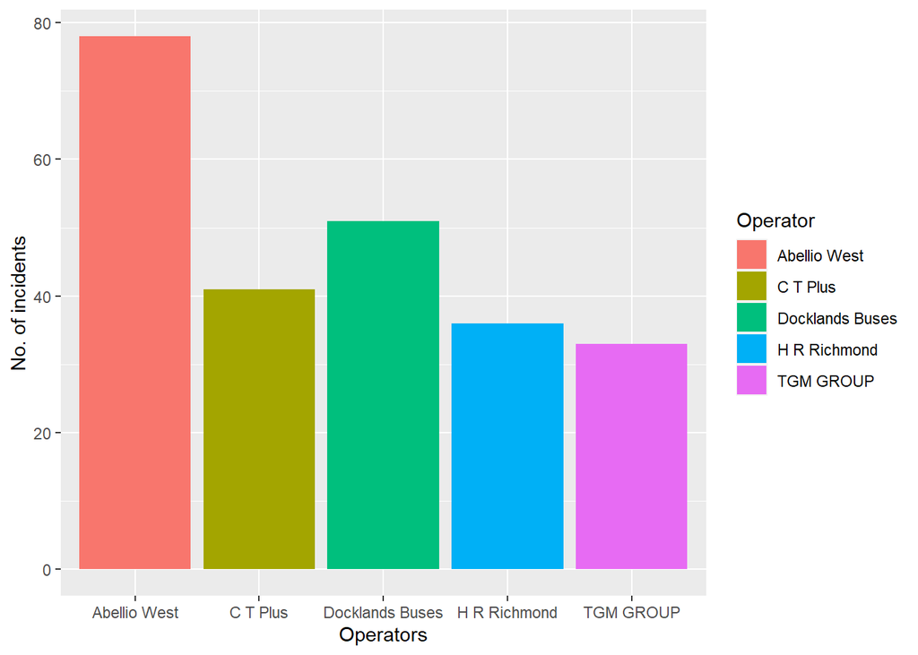

```r
names(safe_operator)<-c("Operator","Counts")
ggplot(data=safe_operator) + geom_bar(mapping = aes(x=Operator,y=Counts,fill=Operator),stat="identity")+ xlab("Operators") + ylab("No. of incidents")
```

### The safest operator overall is “TGM Group”

## 20. Incidents analysis of the Safest operator found

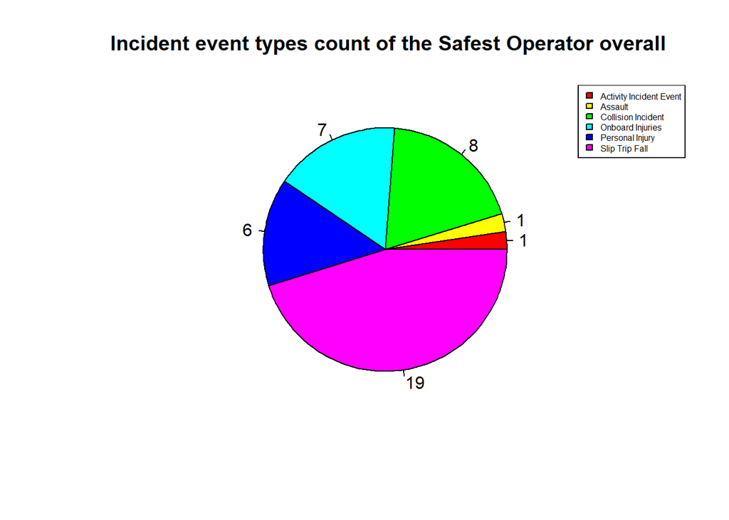

```r
safest_op <- filter(newbus, Operator== "TGM GROUP")


#count
event_count_safe <- table(safest_op$Incident.Event.Type)



# count label safest

lbls_count_safe <- paste( event_count_safe, sep="")


# names label safest
lbls_name_safe <- paste(names(event_count_safe), sep="")



pie(event_count_safe,label= lbls_count_safe, main = " Incident event types count of the Safest Operator overall", col = rainbow(length(event_count_safe)))

legend("topright", lbls_name_safe, cex = 0.5,
       fill = rainbow(length(event_count_safe)))
```

### The count of Slip Trip Fall is the highest

## Analysis

#### From the analysis we have done, we found out that “TGM Group” is the safest operator and “Slip Trip Fall” is the most common incident happened in most of the buses. It is advised that foot board travel should not be encouraged, the foot board of the buses be re-engineered, and boarding a running bus should not be encouraged.

## Conclusion

#### Thus, we as a team have made a data analysis on London Bus Safety Performance dataset and have delivered the insight for the future improvements.

## Reference

https://www.analyticsvidhya.com/blog/2022/03/a-comprehensive-guide-on-ggplot2-in-r/

https://www.javatpoint.com/r-data-visualization